# Untitled

2024-04-10

Pick a TV show that had its premieres on TV and thus has some viewership numbers reported on Wikipedia. E.g. [Suits](https://en.wikipedia.org/wiki/List_of_Suits_episodes) (see table just above the References)

Then create a short report (you can copy the content from Wikipedia or other pages for this task) that contains, for example:

(try doing more than one commit for this, i.e. divide your work into steps!)

1. A brief description of the show (use *italics* for names).
2. A photo with the logo or a shot from the show itself.
3. A summary of some basic statistics (e.g. on viewership or ratings).
4. A graph of the viewership over time.
5. A graph of the episode-to-episode (or season-to-season) changes in viewership.
6. A short description of the observed changes that includes inline references to numbers (e.g. the viewership decreased by `insert_calculated_number` between seasons 3 and 5).
7. Make sure your report looks nice -> this time we’re mostly interested in the output and not necessarily the codes used to achieve it.
8. `render` your report and save it in the relevant folder of your repo.
9. Commit the changes and push them to Github.

selected wikipedia - https://en.wikipedia.org/wiki/List_of_Game_of_Thrones_episodes

## Homework

*Game of Thrones* is an American fantasy drama television series created by *David Benioff* and *D. B. Weiss*. The series is based on George R. R. Martin’s series of fantasy novels, *A Song of Ice and Fire*. The series takes place on the fictional continents of Westeros and Essos, and chronicles the power struggles among noble families as they fight for control of the Iron Throne of the Seven Kingdoms. The series starts when House Stark, led by Lord Eddard “*Ned*” Stark (*Sean Bean*), is drawn into schemes surrounding King Robert Baratheon (*Mark Addy*).

[figure not shown]

Game of Thrones Logo

```
Season 1: Aired from April 17, 2011, to June 19, 2011, with 10 episodes. It averaged 2.52 million U.S. viewers.
Season 2: Also consisted of 10 episodes, airing from April 1, 2012, to June 3, 2012. The average viewership increased to 3.80 million.
Season 3: Continued with 10 episodes, from March 31, 2013, to June 9, 2013, seeing an increase in viewership to 4.97 million.
Season 4: Aired from April 6, 2014, to June 15, 2014, with 10 episodes. The viewership further rose to 6.84 million.
Season 5: Kept the trend of 10 episodes, airing from April 12, 2015, to June 14, 2015, with a slight increase in average viewers to 6.88 million.
Season 6: Also had 10 episodes, aired from April 24, 2016, to June 26, 2016, and witnessed an average viewership of 7.69 million, continuing the trend of increasing popularity.
Season 7: Shortened to 7 episodes, this season aired from July 16, 2017, to August 27, 2017, and marked a significant jump in average viewership to 10.26 million.
Season 8: The final season, consisting of 6 episodes, aired from April 14, 2019, to May 19, 2019. It achieved the highest average viewership of 11.99 million.
```

[figure not shown]

```r
library(ggplot2)
got_data <- data.frame(
  Season = factor(c("2011", "2012", "2013", "2014", "2015", "2016", "2017", "2018"), levels = c("2011", "2012", "2013", "2014", "2015", "2016", "2017", "2018")),
  Viewership = c(2.52, 3.80, 4.97, 6.84, 6.88, 7.69, 10.26, 11.99)
)

ggplot(got_data, aes(x = Season, y = Viewership)) +
  geom_line(group=1) + geom_point() + labs(title = "Game of Thrones Seasonal Viewership Trend", x = "Aired year", y = "Average U.S. Viewership (millions)") + theme_minimal()
```

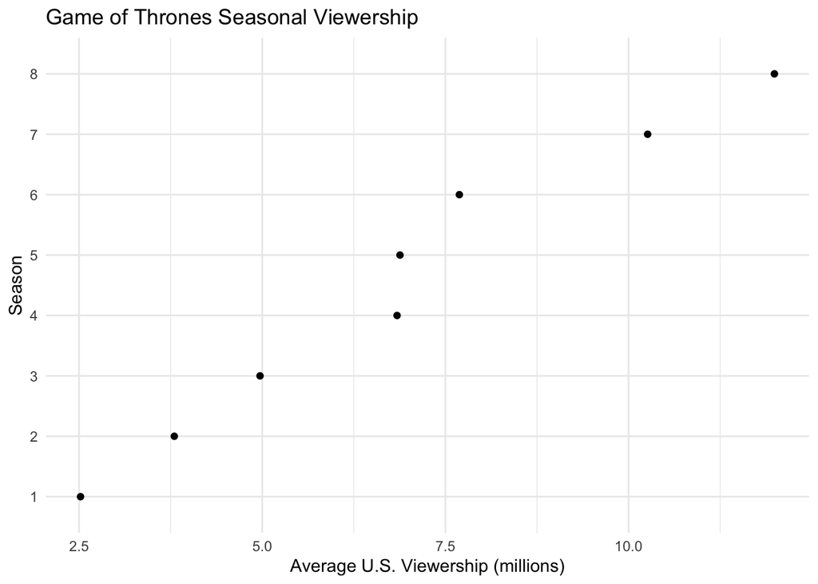

```r
library(ggplot2)

got_data <- data.frame(
  Season = factor(c("1", "2", "3", "4", "5", "6", "7", "8"), levels = c("1", "2", "3", "4", "5", "6", "7", "8")),
  Viewership = c(2.52, 3.80, 4.97, 6.84, 6.88, 7.69, 10.26, 11.99))

ggplot(got_data, aes(x = Viewership, y = Season)) + geom_point() + labs(title = "Game of Thrones Seasonal Viewership", x = "Average U.S. Viewership (millions)", y = "Season") + theme_minimal()
```

The viewership for “Game of Thrones” saw significant growth between season 3 and season 5. Specifically, there was an increase of 1.91 million average U.S. viewers, rising from 4.97 million in the third season to 6.88 million by the fifth season. This surge reflects the series’ growing popularity and increasing engagement with its audience over these seasons.